# Context

Responding to the code [here](https://www.kaggle.com/code/ekrembayar/a-b-testing-step-by-step-hypothesis-testing/notebook).

In the game cookie cats, players encounter gates that force them to wait before progressing or make an in-app purchase. Perform an A/B test where the first gate was moved from level 30 to level 40. Analyze the impact on player retention and game rounds.

## Elaboration

An a/b test needs an hypothesis. I will assume that the company is moving the gate to level 40 because they hypothesise an increase in retention and in game rounds.

## Steps:

- load data
- clean data
- - unique userids
- - misspellings
- - outliers
- - nulls
- check for normal distribution
- perform appropriate tests

# Exploratory Analysis

```r
colnames(df)
```

```
## [1] "userid"         "version"        "sum_gamerounds" "retention_1"
## [5] "retention_7"
```

Check to see if all observations are from unique users.

```r
count(unique(df["userid"]))
```

```
##       n
## 1 90189
```

```r
count(df["userid"])
```

```
##       n
## 1 90189
```

Check that version has only 2 factors

```r
unique(df$version)
```

```
## [1] "gate_30" "gate_40"
```

check for outliers and remove them.

```r
quantile(df$sum_gamerounds, probs = c(.01,0.05, 0.10, 0.20, 0.80, 0.90, 0.95, 0.99, 1))
```

```
##    1%    5%   10%   20%   80%   90%   95%   99%  100%
##     0     1     1     3    67   134   221   493 49854
```

```r
df = df[df$sum_gamerounds < 49854,]
```

check for nulls

```r
sum(is.na(df))
```

```
## [1] 0
```

Comparing the histograms for different versions, we see little difference.

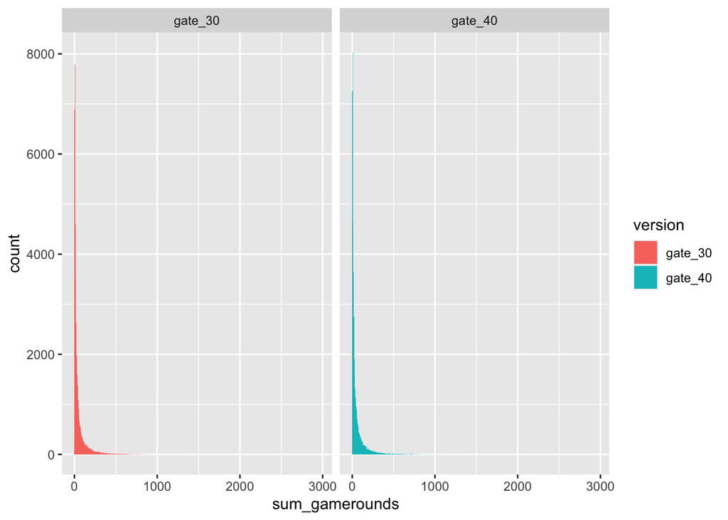

```r
ggplot(df) +
  geom_histogram(aes(sum_gamerounds, fill=version), binwidth = 5) +
  facet_wrap(vars(version))
```

```r
group_by(df, version) %>% summarise(count = n(),
                                    mean = mean(sum_gamerounds),
                                    median= median(sum_gamerounds),
                                    std = sd(sum_gamerounds))
```

```
## # A tibble: 2 × 5
##   version count  mean median   std
##   <chr>   <int> <dbl>  <int> <dbl>
## 1 gate_30 44699  51.3     17  102.
## 2 gate_40 45489  51.3     16  103.
```

Versions differ only slightly in their summary stats. However, we see that the median for gate_30 is higher than the median for gate_40. This indicates that the gate_40 hypothesis is wrong; ie, the treatment didn’t work. We can do a stats test to be sure.

# Test sum_gamerounds

At first blush, it seems reasonable to want to create an all-purpose ab test function, as the original author did. However, there are some variables like wilcoxon test alternative that can’t be factored out without knowing information about the dataset beforehand. At the same time, other ab testing methods like linear regression or bayesian inference would give different outputs for the given input, and also require different inputs. It makes more sense to perform this ab test ad-hoc. If there is a system in place that is creating a standardized form of ab-test that needs to be performed repeatedly, then it would make sense to make a function.

If the data was normal, we would use a t.test, where variance equivalence would be determined by a levene test. We can check normality with an anderson darling or shapiro test, using anderson darling for larger sample sizes.

We know our data is non-parametric from the graphs above, so we use a wilcox test, or the mann-whitney test. We are checking to see if the median of the gate_30 group is less than the median of the gate_40 group.

```r
print(wilcox.test(sum_gamerounds~version,
  df,
  alternative="l"))
```

```
##
##  Wilcoxon rank sum test with continuity correction
##
## data:  sum_gamerounds by version
## W = 1024285762, p-value = 0.9746
## alternative hypothesis: true location shift is less than 0
```

As expected, the p.value is much greater than .05, and the hypothesis is false. Our original author wasn’t clear about the hypothesis he was testing, and he didn’t realize his function in python used a greater than alternative, which led to his statistically significant result.

However, there’s more to the story.

# Removing Noise From the Data

Our data includes a significant number of users who weren’t exposed to either gate 30 or gate 40. As they aren’t relevant to the study, we should exclude them.

```r
df2 = df[df$sum_gamerounds >= 30,]
group_by(df2, version) %>% summarise(count = n(),
                                    mean = mean(sum_gamerounds),
                                    median= median(sum_gamerounds),
                                    std = sd(sum_gamerounds))
```

```
## # A tibble: 2 × 5
##   version count  mean median   std
##   <chr>   <int> <dbl>  <int> <dbl>
## 1 gate_30 16655  122.     72  141.
## 2 gate_40 16613  124.     75  144.
```

We removed more than half of the players, which increased the difference in mean and median between the two groups. Now, the hypothesis seems plausible. We test to see if the median of gate_30 is less than that of gate_40.

```r
print(wilcox.test(sum_gamerounds~version,
  df2,
  alternative="l"))
```

```
##
##  Wilcoxon rank sum test with continuity correction
##
## data:  sum_gamerounds by version
## W = 134945870, p-value = 5.204e-05
## alternative hypothesis: true location shift is less than 0
```

```r
print(wilcox_effsize(df2,
  sum_gamerounds~version,
  paired=FALSE,
  alternative = "l"))
```

```
## # A tibble: 1 × 7
##   .y.            group1  group2  effsize    n1    n2 magnitude
## * <chr>          <chr>   <chr>     <dbl> <int> <int> <ord>
## 1 sum_gamerounds gate_30 gate_40  0.0213 16655 16613 small
```

Here we have a highly significant p.value, with an insignificant effect size. For reference, effect size range from 0 to 1, with 0.10 - < 0.3 (small effect), 0.30 - < 0.5 (moderate effect) and >= 0.5 (large effect).

This means that the hypothesis fails again.

# Retention Rates

```r
as_tibble(list(
  "value" = c("false", "true"),
"ret1" = df2$retention_1 %>% table(),
"ret7" = df2$retention_7 %>% table(),
"ret1ratio" = round(table(df2$retention_1)/nrow(df2),2),
"ret7ratio" = round(table(df2$retention_7)/nrow(df2),2)
))
```

```
## # A tibble: 2 × 5
##   value ret1        ret7        ret1ratio   ret7ratio
##   <chr> <table[1d]> <table[1d]> <table[1d]> <table[1d]>
## 1 false  6606       18817       0.2         0.57
## 2 true  26662       14451       0.8         0.43
```

There is a very small difference of mean retention between versions.

```r
group_by(df2, version) %>% summarise(
  "ret1mean" = mean(retention_1),
  "ret7mean"=mean(retention_7),
)
```

```
## # A tibble: 2 × 3
##   version ret1mean ret7mean
##   <chr>      <dbl>    <dbl>
## 1 gate_30    0.801    0.439
## 2 gate_40    0.802    0.430
```

We’ll test if this is statistically significant with a chi-square test.

```r
Cramers_V <- function(chi, n, degFree=1) sqrt((chi)/(n * degFree))

print('day 1 retention:')
```

```
## [1] "day 1 retention:"
```

```r
print(chisq.test(df2$version, df2$retention_1))
```

```
##
##  Pearson's Chi-squared test with Yates' continuity correction
##
## data:  df2$version and df2$retention_1
## X-squared = 0.030274, df = 1, p-value = 0.8619
```

```r
print('day 7 retention:')
```

```
## [1] "day 7 retention:"
```

```r
d7rettest = chisq.test(df2$version, df2$retention_7)
print(d7rettest)
```

```
##
##  Pearson's Chi-squared test with Yates' continuity correction
##
## data:  df2$version and df2$retention_7
## X-squared = 2.5283, df = 1, p-value = 0.1118
```

```r
print('effect size:')
```

```
## [1] "effect size:"
```

```r
Cramers_V(d7rettest$statistic, sum(table(df2[c("version", "retention_7")])))
```

```
##   X-squared
## 0.008717704
```

# Improving the Study

To increase the power of the study, we might integrate other observations that may have had an impact on retention or game rounds. To integrate more data, I would use multiple linear regression and/or Anova.

Given demographic information, we could also stratify the study on various categories to see if there was a more significant effect for certain subgroups.